# Homework 08

STAT 432

Author

Haoran Sun

Published

October 17, 2026

The former kernel-tuning question has moved to Homework 09.

Solutions for Questions 1 and 2 will be available after Monday, October 19, 2026. No solution can be provided for Question 3.

For Questions 1 and 2, use either R or Python.

## Question 1: Boundary and margin

Use `margin-geometry-20.csv` from the combined ZIP, which contains 20 observations with predictors $x_1,x_2$ and class labels $y\in\{-1,1\}$. Consider the score

$$f(x)=0.8x_1+0.6x_2.$$

Since $\|(0.8,0.6)\|_2=1$, the lines $f(x)=\pm1$ are each a distance 1 from the decision boundary $f(x)=0$.

1. Calculate the distance from every observation to the decision boundary and its functional margin $yf(x)$. In a table, report these values and whether each observation is inside, on, or beyond the margin for its class. Compare $yf(x)$ with 1 to make this distinction.

#### Answer 1(a)

```python
import numpy as np
import pandas as pd

points = pd.read_csv("data/margin-geometry-20.csv")
X = points[["x1", "x2"]].to_numpy()
y = points["y"].to_numpy()
beta = np.array([0.8, 0.6])
scores = X @ beta

distances = np.abs(scores) / np.linalg.norm(beta)
functional_margins = y * scores

on_margin = np.isclose(functional_margins, 1.0, rtol=0, atol=1e-10)
margin_category = np.where(
    on_margin, "On", np.where(functional_margins < 1, "Inside", "Beyond")
)
results_1a = pd.DataFrame({
    "Observation": points["observation"],
    "Class": y,
    "Distance to boundary": distances,
    "Functional margin": functional_margins,
    "Category": margin_category
})
print(results_1a.to_string(index=False, float_format="%.2f"))
```

```
 Observation  Class  Distance to boundary  Functional margin Category
           1      1                  1.00               1.00       On
           2      1                  1.35               1.35   Beyond
           3      1                  1.50               1.50   Beyond
           4      1                  1.70               1.70   Beyond
           5      1                  1.90               1.90   Beyond
           6      1                  2.20               2.20   Beyond
           7      1                  2.40               2.40   Beyond
           8      1                  0.64               0.64   Inside
           9      1                  0.20               0.20   Inside
          10      1                  0.20              -0.20   Inside
          11     -1                  1.00               1.00       On
          12     -1                  1.30               1.30   Beyond
          13     -1                  1.55               1.55   Beyond
          14     -1                  1.75               1.75   Beyond
          15     -1                  1.95               1.95   Beyond
          16     -1                  2.15               2.15   Beyond
          17     -1                  2.45               2.45   Beyond
          18     -1                  0.64               0.64   Inside
          19     -1                  0.24               0.24   Inside
          20     -1                  0.20              -0.20   Inside
```

The distance is $|f(x)|/\|\boldsymbol{\beta}\|=|f(x)|$, since $\|\boldsymbol{\beta}\|=1$. An observation is inside, on, or beyond its class margin when $yf(x)$ is less than, equal to, or greater than 1, respectively. Negative functional margins indicate observations on the wrong side of the decision boundary.

2. Plot the observations, the boundary $f(x)=0$, and the margin lines $f(x)=\pm1$. Distinguish the two classes and identify the observations inside the margin in your plot.

#### Answer 1(b)

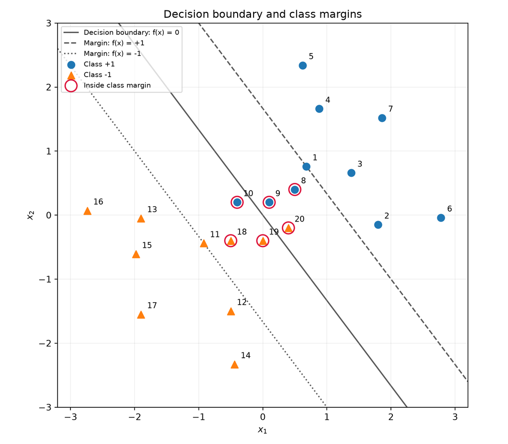

```python
import matplotlib.pyplot as plt

fig, ax = plt.subplots(figsize=(8, 7))
x1_grid = np.linspace(-3.2, 3.2, 300)
# Solve 0.8*x1 + 0.6*x2 = level for x2.
for level, style, label in [
    (0, "-", "Decision boundary: f(x) = 0"),
    (1, "--", "Margin: f(x) = +1"),
    (-1, ":", "Margin: f(x) = -1")
]:
    ax.plot(x1_grid, (level - 0.8 * x1_grid) / 0.6,
            color="0.35", linestyle=style, label=label, zorder=1)

for label, color, marker in [(1, "tab:blue", "o"), (-1, "tab:orange", "^")]:
    mask = y == label
    ax.scatter(X[mask, 0], X[mask, 1], color=color, marker=marker,
               s=65, label=f"Class {label:+d}", zorder=3)

inside = margin_category == "Inside"
ax.scatter(X[inside, 0], X[inside, 1], s=180,
           facecolors="none", edgecolors="crimson", linewidths=1.5,
           label="Inside class margin", zorder=4)

for observation, (x1, x2) in zip(points["observation"], X):
    ax.annotate(str(observation), (x1, x2), xytext=(7, 7),
                textcoords="offset points", fontsize=9, zorder=5)

ax.set(xlabel=r"$x_1$", ylabel=r"$x_2$",
       title="Decision boundary and class margins",
       xlim=(-3.2, 3.2), ylim=(-3, 3))
ax.set_aspect("equal", adjustable="box")
ax.grid(alpha=0.2)
ax.legend(loc="upper left", fontsize=8)
fig.tight_layout()
plt.show()
```

Red rings identify observations inside their class margin; the numbers are the observation IDs supplied in the data.

3. Report how many observations are inside, on, and beyond the margin. Which observations are misclassified by this decision rule?

Use the observation numbers supplied in the data. Set the $x_1$ axis to $[-3.2,3.2]$, set the $x_2$ axis to $[-3,3]$, and use an equal aspect ratio. Do not fit a new classifier for this question.

#### Answer 1(c)

```python
counts = pd.Series(margin_category).value_counts().reindex(
    ["Inside", "On", "Beyond"], fill_value=0
)
print(counts.rename_axis("Category").to_frame("Count"))
```

```
          Count
Category
Inside        6
On            2
Beyond       12
```

```python
# A negative functional margin means the score has the wrong sign.
misclassified = points.loc[functional_margins < 0, "observation"].tolist()
print("\nMisclassified observation IDs:", misclassified)
```

```
Misclassified observation IDs: [10, 20]
```

There are **6 inside**, **2 on**, and **12 beyond** their class margin. Observations **10 and 20** are misclassified: both have functional margin $yf(x)=-0.20$.

## Question 2: Margin in four dimensions

Use `margin-geometry-4d.csv` from the combined ZIP, which contains 50 observations with four predictors and class labels $y\in\{-1,1\}$. Consider the linear score

$$f(\mathbf{x})=\beta_0+\mathbf{x}^{\mathsf T}\boldsymbol{\beta},
\qquad
\beta_0=-1,
\quad
\boldsymbol{\beta}=(1,2,-2,4)^{\mathsf T}.$$

1. Project the observations onto the direction of $\boldsymbol{\beta}$ and plot their positions on one axis. Distinguish the two classes and mark the decision boundary. Use the plot to calculate the geometric margin $M$, the distance from the boundary to the closest observation.

#### Answer 2(a)

```python
points_4d = pd.read_csv("data/margin-geometry-4d.csv")
X_4d = points_4d[["x1", "x2", "x3", "x4"]].to_numpy()
y_4d = points_4d["y"].to_numpy()
beta_4d = np.array([1, 2, -2, 4])
beta0_4d = -1
beta_norm = np.linalg.norm(beta_4d)
unit_beta = beta_4d / beta_norm

projection = X_4d @ unit_beta
boundary = -beta0_4d / beta_norm
distance_4d = np.abs(projection - boundary)
M = distance_4d.min()
closest = np.isclose(distance_4d, M, rtol=0, atol=1e-10)
print(f"Norm of beta: {beta_norm:.1f}")
```

```
Norm of beta: 5.0
```

```python
print(f"Projected decision boundary: {boundary:.2f}")
```

```
Projected decision boundary: 0.20
```

```python
print(f"Geometric margin M: {M:.4f}")
```

```
Geometric margin M: 1.0000
```

```python
print("Closest observations:")
```

```
Closest observations:
```

```python
print(pd.DataFrame({
    "Observation": points_4d.loc[closest, "observation"],
    "Projection": projection[closest],
    "Distance": distance_4d[closest]
}).to_string(index=False, float_format="%.4f"))
```

```
 Observation  Projection  Distance
           4      1.2000    1.0000
          15     -0.8000    1.0000
          33      1.2000    1.0000
          36     -0.8000    1.0000
```

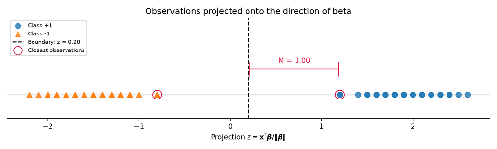

```python
fig, ax = plt.subplots(figsize=(10, 3))
ax.axhline(0, color="0.75", linewidth=1, zorder=1)
for label, color, marker in [(1, "tab:blue", "o"), (-1, "tab:orange", "^")]:
    mask = y_4d == label
    ax.scatter(projection[mask], np.zeros(mask.sum()), color=color,
               marker=marker, s=60, alpha=0.8, label=f"Class {label:+d}", zorder=3)
ax.axvline(boundary, color="black", linestyle="--",
           label=f"Boundary: z = {boundary:.2f}")
ax.scatter(projection[closest], np.zeros(closest.sum()), s=160,
           facecolors="none", edgecolors="crimson", label="Closest observations", zorder=4)

# Show the distance from the boundary to one closest observation.
nearest_z = projection[np.argmin(distance_4d)]
ax.annotate("", xy=(boundary, 0.16), xytext=(nearest_z, 0.16),
            arrowprops=dict(arrowstyle="|-|", color="crimson"))
ax.text((boundary + nearest_z) / 2, 0.20, f"M = {M:.2f}",
        ha="center", color="crimson")
ax.set(xlabel=r"Projection $z = \mathbf{x}^{\mathsf{T}}\boldsymbol{\beta}/\|\boldsymbol{\beta}\|$",
       title="Observations projected onto the direction of beta",
       yticks=[], ylim=(-0.15, 0.48))
ax.spines[["left", "right", "top"]].set_visible(False)
ax.legend(loc="upper left", fontsize=8)
fig.tight_layout()
plt.show()
```

Since $\|\boldsymbol{\beta}\|=5$, the projected coordinate is $z=(x_1+2x_2-2x_3+4x_4)/5$ and the boundary is $z=0.2$. The closest projected positions are $z=-0.8$ and $z=1.2$, so the geometric margin is $M=\min_i|z_i-0.2|=1$. Observations 4, 15, 33, and 36 attain this distance.

2. Express the same decision boundary using the SVM normalization in which the smallest functional margin $y_i f(\mathbf{x}_i)$ is set to 1. What are the corresponding values of $\boldsymbol{\beta}$ and $\beta_0$?

#### Answer 2(b)

```python
scores_4d = beta0_4d + X_4d @ beta_4d
min_functional_margin = np.min(y_4d * scores_4d)

beta_svm = beta_4d / min_functional_margin
beta0_svm = beta0_4d / min_functional_margin
normalized_scores = beta0_svm + X_4d @ beta_svm

print(f"Original minimum functional margin: {min_functional_margin:.4f}")
```

```
Original minimum functional margin: 5.0000
```

```python
print("Normalized beta:", beta_svm)
```

```
Normalized beta: [ 0.2  0.4 -0.4  0.8]
```

```python
print(f"Normalized intercept: {beta0_svm:.4f}")
```

```
Normalized intercept: -0.2000
```

```python
print(f"New minimum functional margin: {np.min(y_4d * normalized_scores):.4f}")
```

```
New minimum functional margin: 1.0000
```

```python
assert min_functional_margin > 0
assert np.isclose(np.min(y_4d * normalized_scores), 1)
assert np.allclose(normalized_scores, scores_4d / min_functional_margin)
```

The smallest functional margin is 5, so divide both the intercept and coefficient vector by 5:

$$\boldsymbol{\beta}_{\mathrm{SVM}}=(0.2,0.4,-0.4,0.8)^{\mathsf T},
\qquad \beta_{0,\mathrm{SVM}}=-0.2.$$

Then $\min_i y_i f_{\mathrm{SVM}}(\mathbf{x}_i)=1$. Multiplying the score by the positive constant $1/5$ preserves its zero set and sign, so the decision boundary and predictions are unchanged.

## Question 3: Peer review of a Homework 7 skill

The instructor’s GitHub account, **rqzhu-aide**, will open a **GitHub Issue** in the repository containing your Homework 7 submission. It will link to **one** assigned student’s repository.

1. **Use the skill.** Find the complete skill definition in the assigned student’s Homework 7 report. Copy it without changes into a local `SKILL.md` file in your own folder. You do not need to install it. Give your agent the path to the file and explicitly ask it to follow that skill while analyzing the `SAheart` data, using the response and predictor coding from Homework 7. Provide the necessary data information, but no additional preferences about methods, figures, model selection, or report style. Let the skill direct the analysis.

   Monitor the time, your token use, and your weekly quota while the agent works. If the run is taking too long or using your allowance too quickly, you may send a **steer message** asking the agent to finish immediately, or stop the run and summarize what you observed. A steer message redirects an agent while it is working; learn how to send one in your AI tool before starting.

#### Answer 3(1)

Assigned repository: ec-03/stat432-fall2026. I used the [provided skill](https://github.com/ec-03/stat432-fall2026/blob/main/homework/week-07/SKILL.md).

The agent chose seed 43283 and followed the skill’s candidate models, 25% test split, and shared 10-fold CV. It selected PCA + LDA with 6 components (CV error 0.2634). Its test error was 30/116 = 0.2586, with 95% Wilson interval [0.1876, 0.3451].

The generated PDF was checked to contain one letter-size page. Its contents are included below.

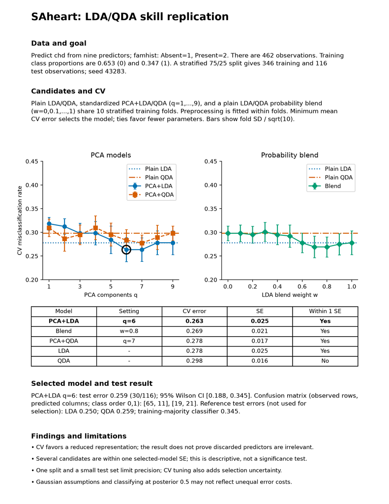

2. **Write a peer review.** Read the student’s submitted report and what the skill produced in your run. Give a brief overall assessment, followed by **three major items the author could improve**. You may comment on any aspect of the skill or report. For each item, explain what you observed, why it matters, and what you recommend changing. If you stopped the run early, explain where and why. Write the review yourself, without AI assistance.

#### Answer 3(2)

Overall, the skill is well organized: it keeps preprocessing inside cross-validation, reserves a test set, and produces a readable one-page report. My run completed without fitting warnings and selected PCA + LDA with 6 components (CV error 0.263; test error 0.259).

**Avoid treating the one-SE comparison as a statistical test.** On page 6, the report says the top four candidates are “statistically indistinguishable.” Being within one model’s SE does not establish equal performance, and the fold errors are dependent because the training folds overlap. Change this to “the CV errors are close relative to the reported variability” and state in the skill that the Within 1 SE column is descriptive, not a significance or equivalence test.

**Separate the observed model ranking from its proposed explanation.** Page 6 attributes QDA’s poorer result to extra variance and insufficient curvature. The CV comparison does not directly measure either of these. Also, QDA estimates 90 covariance entries versus LDA’s 45 for nine predictors, so it has 45 additional covariance parameters, not 90 additional ones. Report the observed CV ranking, correct the parameter comparison, and describe higher estimation variance as a possible explanation rather than a demonstrated cause.

**Specify what to do when a candidate cannot be fitted.** The skill asks the agent to check covariance singularity and report QDA warnings, but gives no clear action if a covariance matrix is singular or a class has too few observations for ten folds. My run had no such warnings, but another dataset could cause failure or lead the agent to silently change the method. Add a rule to check class counts first, report failed candidates and affected folds, and exclude invalid candidates from selection without silently adding regularization or dropping predictors.

3. **Share your review.** Open a GitHub Issue in the assigned student’s Homework 7 repository containing your review. Copy the same review into your Homework 8 submission report and include a link to the GitHub Issue.

#### Answer 3(3)

See review in above section. Link to the [Github Issue](https://github.com/ec-03/stat432-fall2026/issues/6).